# Half of Nearby Galaxies Hide an Active Black Hole

Author

TidyTuesday | 2026-08-11

Published

August 11, 2026

## Introduction

Point a spectrograph at the centre of a nearby galaxy and — around **half the time** — you will find a **supermassive black hole actively swallowing matter**. That was the surprise of the *Palomar Spectroscopic Survey of Nearby Galaxies*: in the 1990s, astronomers used the 200-inch Hale Telescope — then the world’s largest — to split the light of 486 galaxy nuclei into spectra and classify what powered each one (Ho, Filippenko & Sargent 1995, 1997, 2009).

This report explores the collected data with three questions, all of which turn into clear, standalone visuals.

## The Three Questions

1. **Can two emission-line ratios separate star-forming galaxies from black holes?** The famous **BPT diagram** ([Baldwin, Phillips & Terlevich 1981](https://ned.ipac.caltech.edu/level5/Glossary/Essay_bpt.html));
2. **Does a galaxy’s *shape* predict what happens at its centre?** — morphology vs. nuclear activity along the Hubble sequence;
3. **Do more massive galaxies host more active nuclei?** — stellar velocity dispersion (a black-hole-mass proxy) vs. activity type.

## Data & Methodology

- **Source:** Palomar Spectroscopic Survey, via [VizieR](https://vizier.cds.unistra.fr/viz-bin/VizieR-2?-source=J/ApJS/112/315) (Ho, Filippenko & Sargent 1995, 1997, 2009).
- **Probe:** optical emission-line spectra of 486 galaxy nuclei taken with the Hale Telescope.
- **Classification:** each nucleus is typed as **H II** (star formation), **Seyfert** (luminous AGN), **LINER** (low-ionisation AGN), **Transition** (composite), or **Absorption**. 415 nuclei are classified; 71 lack detectable emission lines.
- **BPT ratios:** the dataset’s `log_*` columns are *linear* intensity ratios, not logarithms — `log10()` is applied here to build the diagram (see `analysis.R`).

| Activity | Galaxies | Share of classified |
| --- | --- | --- |
| H II | 203 | 48.9% |
| LINER | 94 | 22.7% |
| Transition | 65 | 15.7% |
| Seyfert | 52 | 12.5% |
| Absorption | 1 | 0.2% |

> **Data quality note.** About 15% of survey galaxies have no emission lines and cannot be classified. Roughly one in five classifications is flagged *uncertain* or *very uncertain* — these are drawn faded in Figure 1. No physical claims beyond the reported classifications: this is a demographics snapshot of the local universe.

## Finding 1 — Two line ratios split star formation from black holes

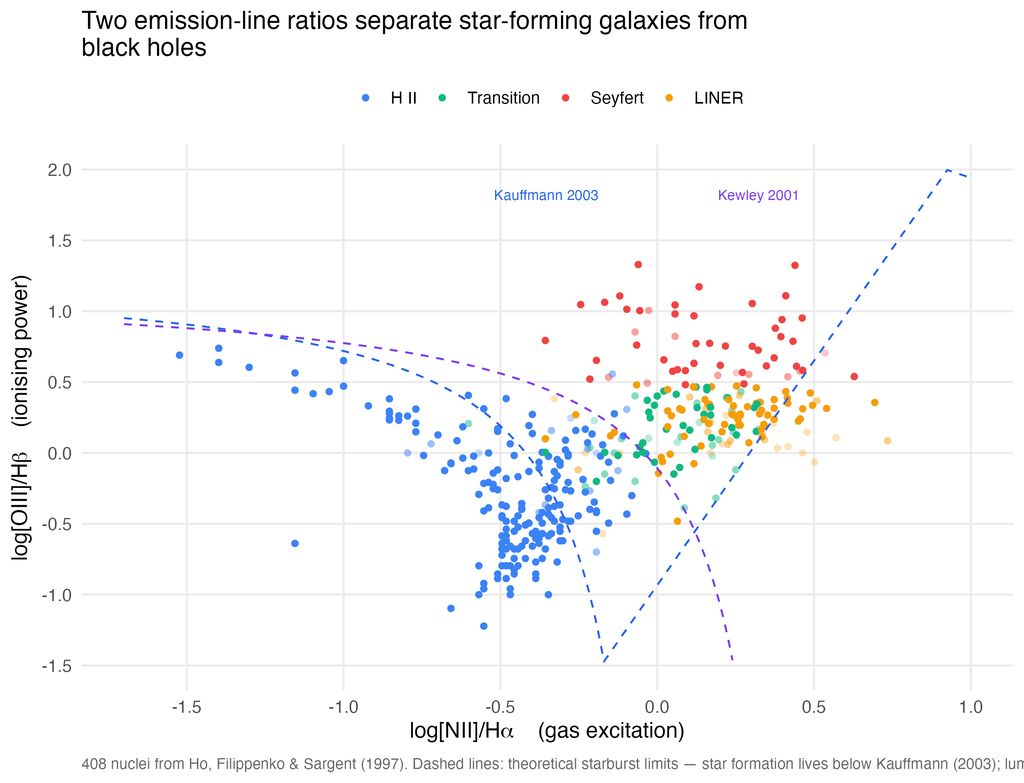

The diagram works like a referee: it separates **photoionisation by young stars** (H II regions) from **photoionisation by a black hole’s accretion disk** (AGN). The *ionising power* axis (y) is what does the heavy lifting:

- **Seyfert nuclei** cluster at the top — median 0.75 in log[OIII]/Hβ, the signature of hard, energetic radiation;
- **H II galaxies** sit at the bottom-left at -0.31 — soft, stellar radiation;
- **LINERs** occupy the right-hand side: enough gas to glow, but too little ionising power to be a classic active nucleus.

The dashed boundaries (Kauffmann 2003 / Kewley 2001) are theoretical limits: nearly all star-forming galaxies fall *below* the blue line, and *above* the purple line star formation is no longer a plausible engine.

## Finding 2 — Shape predicts destiny

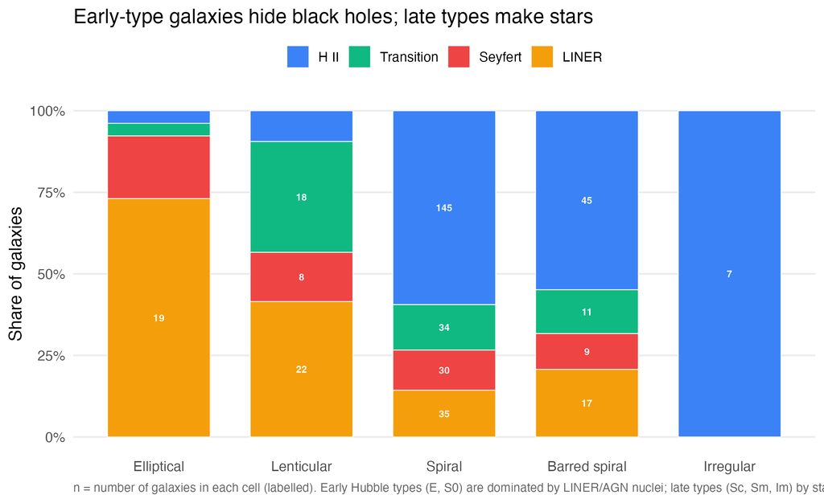

| Morphology | Dominant nucleus | Share |
| --- | --- | --- |
| Elliptical | LINER (AGN) | **73%** |
| Lenticular (S0) | LINER / Transition | 42% / 34% |
| Spiral | H II (star-forming) | **59%** |
| Barred spiral | H II | 55% |
| Irregular | H II | 100% |

Scrolling along the Hubble sequence, the galaxy’s *soul* changes: **early-type, gas-poor systems (E, S0) host quiet, low-luminosity AGN (LINERs), while late-type, gas-rich systems (spirals, irregulars) are full of young stars**. This is a demographics result of the local universe — most galaxies are either “asleep giants” or “star factories”, with relatively few in between.

## Finding 3 — Bigger galaxies, busier black holes

[figure not shown]

*Alt text: vertical violin plots of stellar velocity dispersion (log scale) by activity type, ordered H II, Transition, Seyfert, LINER. Filled by activity colour with jittered points; white dots mark medians (70, 135, 149, 167 km/s). Dispersion rises from H II to LINER.*

The **M-sigma relation** ties a galaxy’s central black-hole mass to its stellar velocity dispersion: measure σ and you have a handle on the black hole. Splitting the sample by activity reveals a clean ladder:

- **H II (star-forming)** nuclei live in the *lightest* galaxies — median 69.8 km/s;
- **LINER** nuclei, in the *heaviest* — median 167 km/s;
- **Seyferts** and transitions sit between (148.75 and 135.3 km/s).

More massive galaxy → more massive black hole → a more energetic (or at least more recognisable) active nucleus. Exactly the demographics the Palomar team reported by eye in 1997, now visible in one panel.

## The Big Picture

Put the three figures back together: **black holes are not rare**. Around 51% of nearby galaxies show some AGN signature (Seyfert, LINER, or transition) against **49%** pure star formation. The engine sits in the galaxy’s centre, and how we see it depends on *how massive* the system is and *how much gas* is left to feed it.

## Reproducibility

- `analysis.R` — full pipeline: cleaning, morphology binning, and all three figures.
- `outputs/` — `key_numbers.csv` (all headline statistics) and `hubble_strip.csv`.
- `figures/*.png` — the three charts above.
- Data: `palomar_survey.csv`, `palomar_emission_lines.csv` (TidyTuesday 2026-08-11, via VizieR).

## Data Credit

- **Dataset:** TidyTuesday (2026-08-11) — curated by [Tony Galvan, Golden Dome Data Science](https://github.com/gdatascience).
- **Original source:** Ho, Filippenko & Sargent (1995, 1997, 2009), [VizieR catalogs](https://vizier.cds.unistra.fr/viz-bin/VizieR-2?-source=J/ApJS/112/315). Classification paper: [ApJS 112, 315](https://arxiv.org/abs/astro-ph/9704108).